# Algumas Lições da História do Mercado de Capitais

Ross et al. (2022), capítulo 13

Marcelo S. Perlin

EA-UFRGS

13/04/2026

# Cálculo do retorno do investidor

## Como o investidor ganha dinheiro?

- Um investidor de ações ganha dinheiro com:
  1. valorização das ações
  2. dividendos e outros proventos e distribuições (majoritariamente em dinheiro)

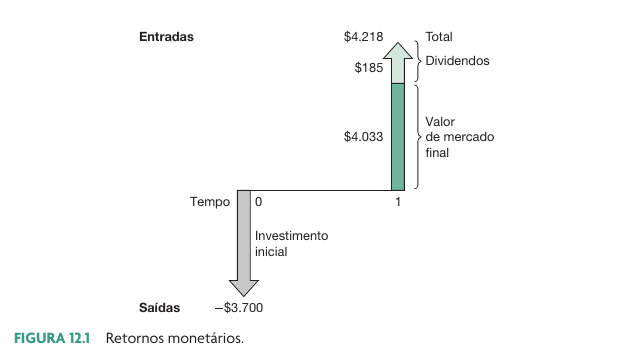

Extraído de Ross et al. (2022), página 391

## Cálculo do Retorno

$$R = \frac{\sum ^N _{i=1} D_i + P_T}{P_0} - 1$$
$R$ - Retorno nominal total do investidor

$D _i$ - Dividendo pago no ano $i$

$P_T$ - Preço de venda no tempo $t=T$

$P_0$ - Preço de compra no tempo $t=0$

## O caso da TAEE11

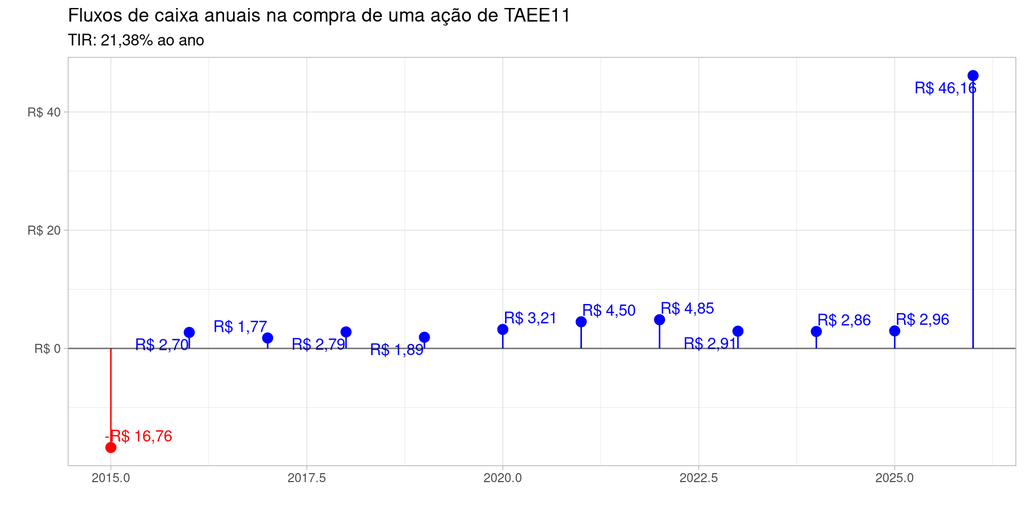

No início de 2015, um investidor da TAEE11 pagou R$ 16,76 por uma ação da empresa. Ao longo dos anos, recebeu R$ 30,45 em dividendos. No ano 2026, a ação foi vendida por R$ 46,16. O retorno total (nominal) do investidor foi de 357,00%.

## A importância do reinvestimento dos dividendos

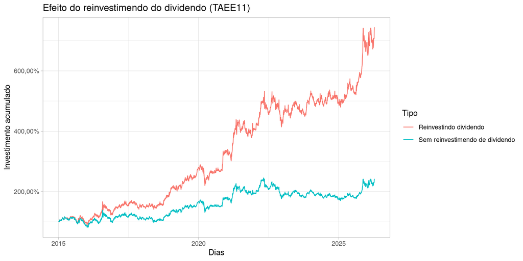

# O Desempenho Histórico do Mercado de Capitais Brasileiro e Americano

## Retornos históricos

- Vamos olhar o desempenho financeiro de três investimentos:
  - Ibovespa (^BVSP) - carteira teórica do mercado de ações
  - CDI (certificado de depósito interbancário)
  - NTN-B Principal 150824 (Tesouro Direto)

## Histórico de Retornos Anuais

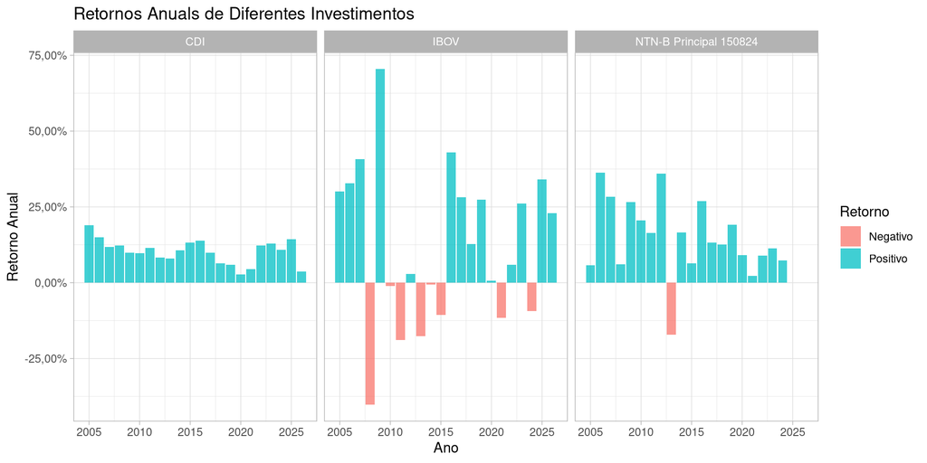

## Retornos acumulados para cada alternativa

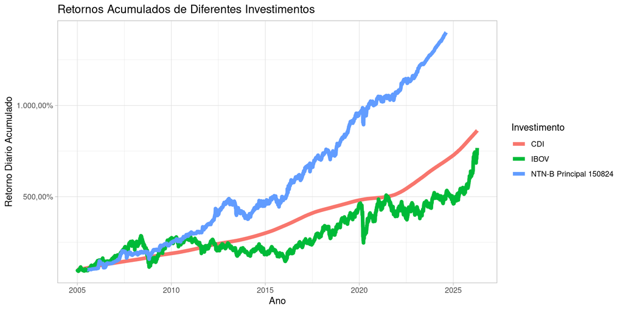

## Desempenho do SP500 (USA)

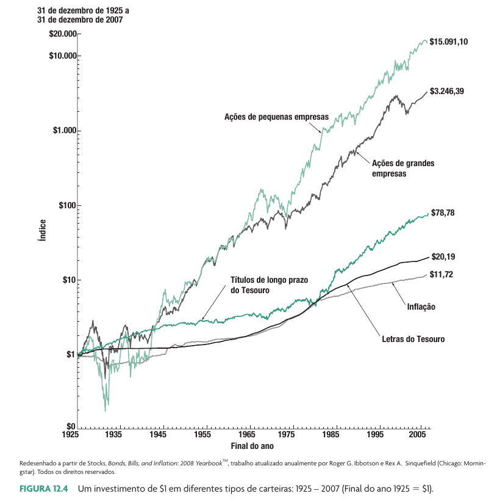

Extraído de Ross et al. (2022), página 395

## Por que o Ibovespa é tão ruim no longo prazo?

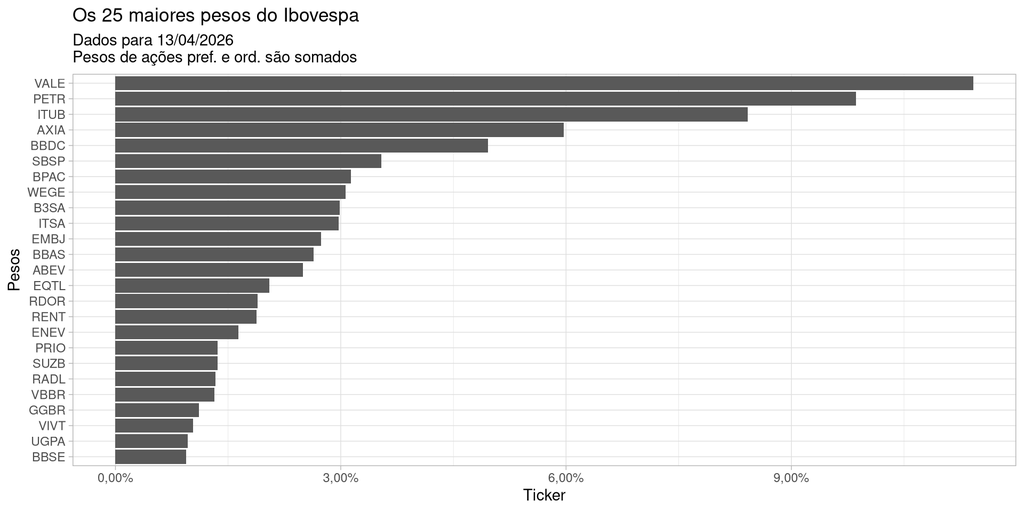

## Riscos históricos

Maiores e menores retornos

| Investimento | Melhor Retorno Anual | Pior Retorno Anual |
| --- | --- | --- |
| CDI | 18.92% | 2.74% |
| IBOV | 70.43% | −40.22% |
| NTN-B Principal 150824 | 36.35% | −17.11% |

# Estatística + Finanças = Teoria de Carteiras

## Distribuições Normais

- Distribuição em formato de curva popularmente usada em estatística e finanças
- Uma das distribuições mais fáceis de se trabalhar
  - É completamente definida por dois parâmetros: a **média** e o **desvio padrão**
- Aplicação direta em financas e investimentos

## Formato da distribuição Normal

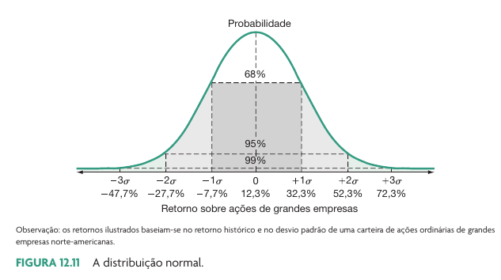

Extraído de Ross et al. (2022), página 407

## Exemplos de Distribuições Normais

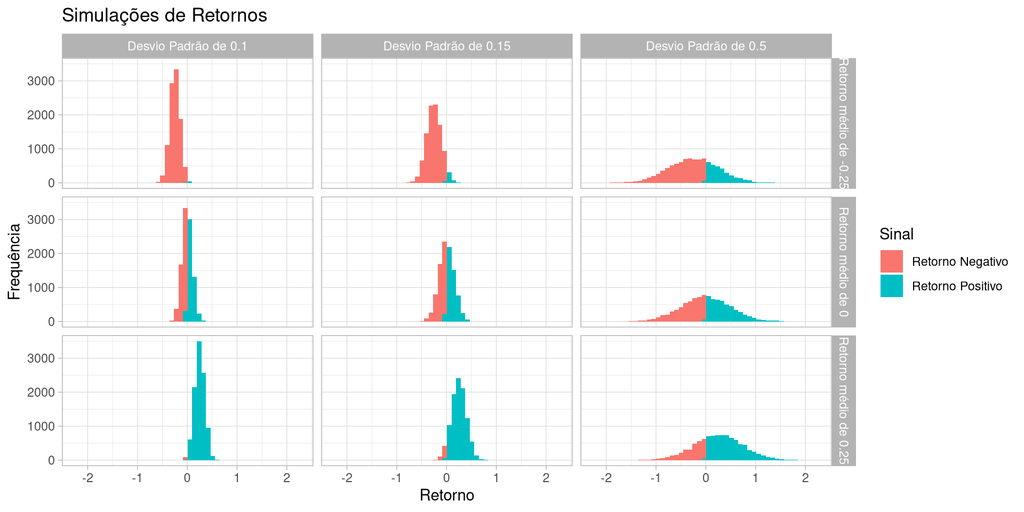

## Definição de Retorno Esperado

> O retorno esperado representa o retorno que um investidor espera ganhar no futuro quando no investimento em uma determinada ação
- Deve ficar claro que:
  - O retorno esperado é uma expectativa. Existe incerteza quanto ao retorno efetivo que o investidor terá
  - O retorno esperado é sempre relativo a um período de tempo
  - O retorno esperado deve ser positivamente relacionado com o risco

**Como calcular tal medida de forma objetiva?**

## Questão #1

Escolha dentre as alternativas abaixo, qual a melhor medida objetiva para calcular retorno anual esperado de uma ação:

1. Realizar um pesquisa com base em analistas de bancos de investimentos e tirar uma média das respostas
2. Realizar um pool no facebook e tirar a média dos resultados
3. Perguntar ao CEO da empresa
4. Calcular como R= SELIC + 5%
5. Tirar uma média dos retornos anuais passados da ação

## Cálculo do Retorno Esperado

> O retorno esperado é uma média simples do retorno histórico do investimento nas ações

$$E(R _t) = E(\frac{P_t - P_{t-1}}{P_t})$$
$$E(R _t) = \frac{\sum ^T _t R_t}{T}$$

## Cálculo do Risco

> O risco nada mais é do que a possibilidade de perda financeira. Quanto maior a possível perda financeira, maior o risco
- A existência do risco é devido:
  - Fluxos de caixa da empresa (e dividendos) são incertos
  - Notícias aleatórias afetam o preço da ação
  - O risco é intrinsicamente relacionado ao retorno esperado
  - Se um investimento qualquer oferece retorno esperado maior que a taxa livre de risco, então este investimento é necessariamente com risco

**Como quantificar o risco?**

## Pergunta #2

Dada uma ação qualquer, qual a melhor maneira objetiva de calcular o risco?

1. Pedir para uma série de analistas votar entre 0 e 10 o risco da ação e tirar a média dos resultados
2. Mandar um questionário para todos os investidores do Brasil perguntando qual o risco de cada ação
3. Verificar qual foi a média das perdas (retornos negativos) da ação nos últimos anos
4. Calcular o desvio padrão dos retornos passados da ação

## Definição Quantitativa de Risco

> O risco é definido como o desvio padrão dos retornos passados dos ativos
- O desvio padrão é uma medida estatística de variação
  - Quanto maior o desvio padrão, maior a variabilidade dos retornos em torno do retorno esperado e consequentemente maior a possibilidade de perdas altas de capital

## Risco e Desvio Padrão

> O Desvio Padrão de uma ação mede a variabilidade dos retornos do título. Quanto maior o desvio padrão, maior a chance de um retorno negativo extremo e maior o risco.

$$\sigma ^2 _{R_t} = E(R_t - E(R_t))^2$$
$$\sigma ^2 _{R_t} = \frac{\sum ^T _{t=1} (R_t - E(R_t))^2}{T-1}$$

$$\sigma _{R_t} = \sqrt{\sigma ^2 _{R_t}}$$

## Exemplo Cálculo Desvio Padrão

[Link GSheets](https://docs.google.com/spreadsheets/d/13FjszjYGPnDm3AUqkxQI7SF7Bm9W-BYn6LdSJNa4jKc/edit?usp=sharing)

## Retornos e Riscos Esperados para o Mercado Brasileiro

Risco e Retorno para diferentes investimentos

| Investimento | Retorno Médio | Risco (Desv. Pad.) |
| --- | --- | --- |
| CDI | 10.31% | 3.97% |
| IBOV | 12.18% | 25.76% |
| NTN-B Principal 150824 | 14.64% | 12.53% |

## Representação Gráfica

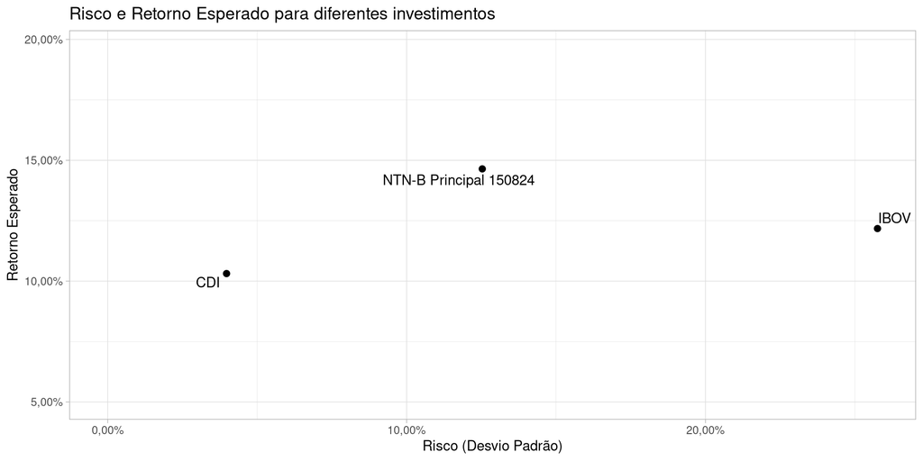

## Referências

Ross, Stephen, Randolph Westerfield, Bradford Jordan, et al. 2022. *Fundamentos de Administração Financeira*. Bookman Editora.